# Week 7 - Chapter 5

Problem #6

In Model 5-2, we assumed that the inspection workers did not overlap between shifts. Modify the model so that the inspectors do overlap for the first hour of one shift and the last hour of the other shift. Compare the results of the two models. Does having the inspectors overlap help?

Original Work Schedule

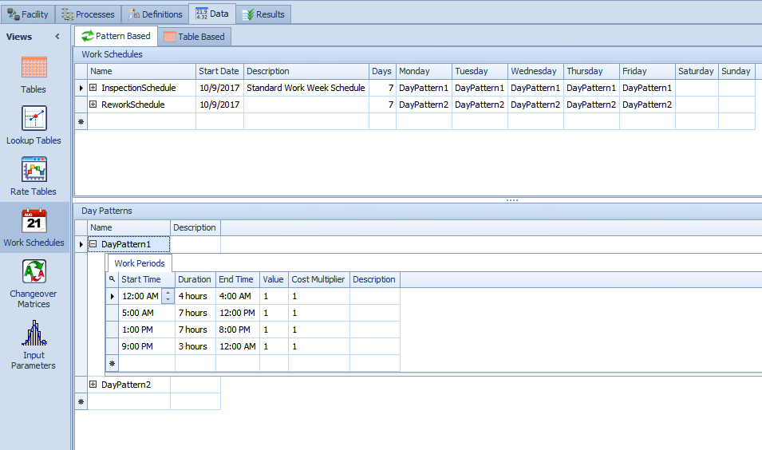

Original Work Schedule Results

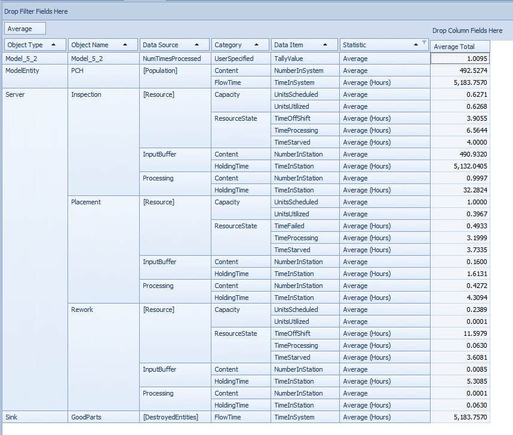

Modified Work Schedule

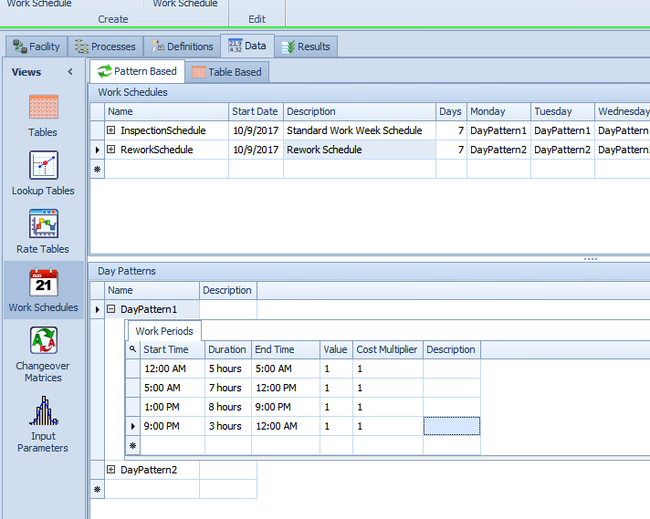

Modified Work Schedule Results

[figure not shown]

The overlap in inspectors does not appear to have actually helped, which seems odd to me. I would have thought that adding more hours to the schedule would have improved our output rate. It’s very possible this is an issue in my model design.

Problem #7

In the description of Model 5-2, we noted that there is no limit on the number of times that a board may be found in need of rework. Modify Model 5-2 so that if a board fails the inspection more than two times, it is rejected as a bad part. Count the number of boards that are rejected because of 3 or more failures.

> I originally set up the Model to include the rejection at 3 failed attempts at processing. I changed the parameters back to a simple model without limits on rejection.

No Limits on Rejection

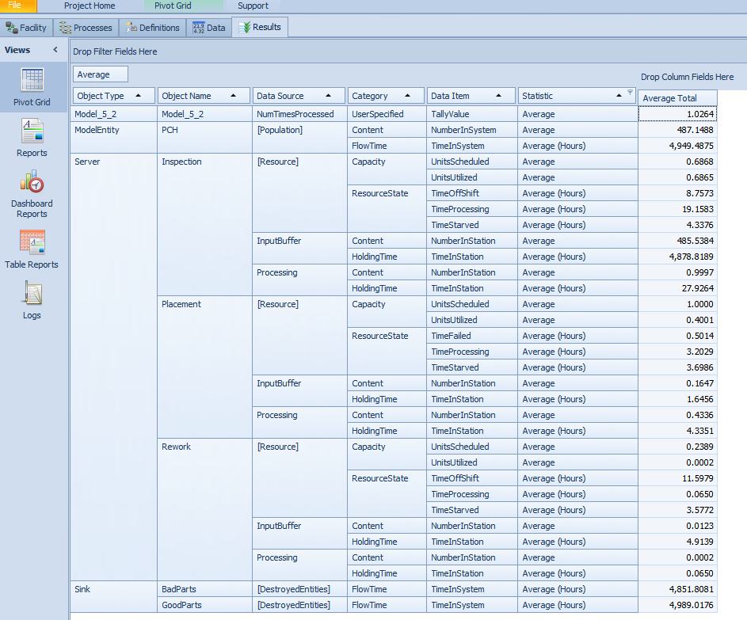

Limits on Rejection

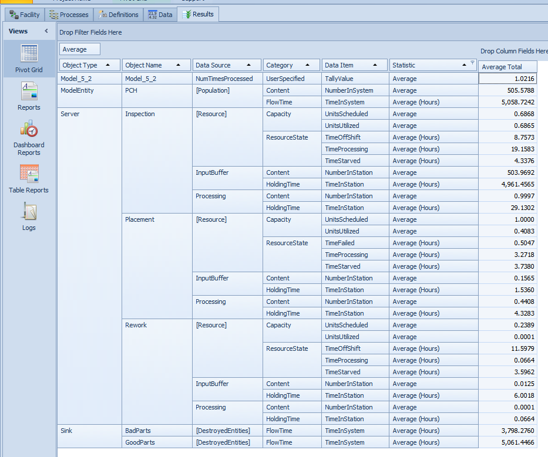

Problem #8

In the description of Model 5-3, we indicated that as part of our model verification, we had predicated the proportions of parts that would go to the fast, medium and slow fine-pitch placement machines (38%, 33%, and 29%, respectively). Develop a queuing model to estimate these proportions.

> Unfortunately, I could not get Simio to route the entities via the node to multiple stations. The model appeared to only route to the FastPitch server even when the node list was set and the smallest value was set as the selection goal. I would appreciate any feedback since I am the stage where I beginning to believe it may be a bug in my model or an obscure setting that I cannot locate.

Pitch Machine Model Design

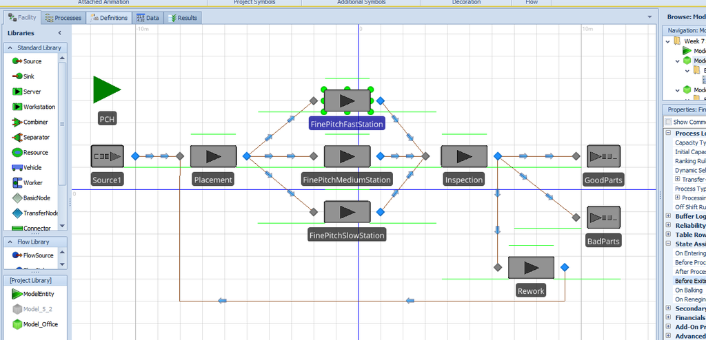

Model Results

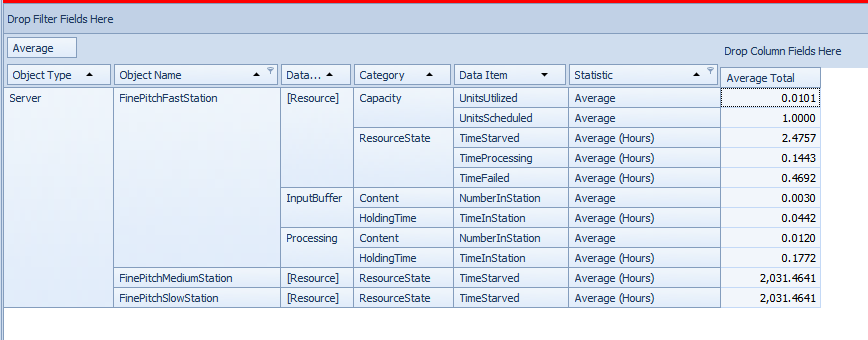

Node Set up

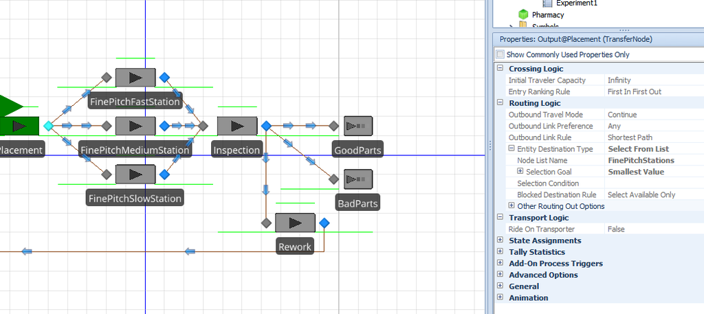

Problem #9

See book for description of problem.

I set up the model as below:

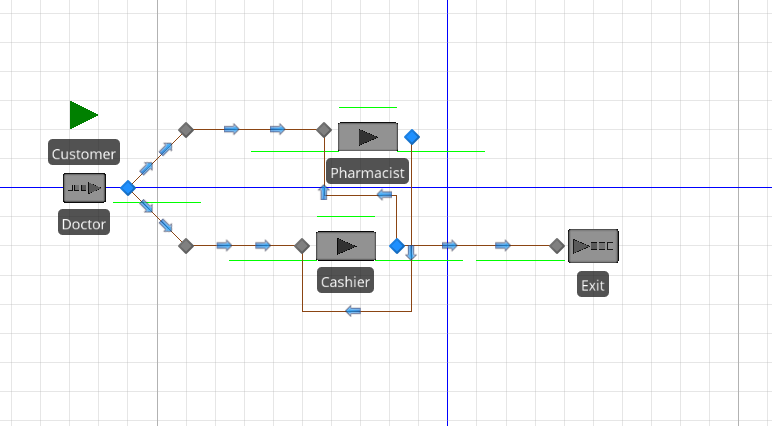

With the following schedule:

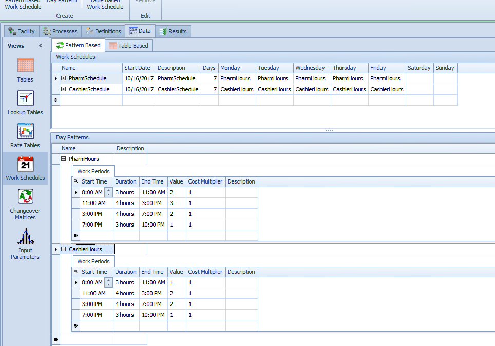

I set states to track when a value changes within the system. I set the customer entity to only leave once they object goes from the cashier and the FromPharma state is set to true.

Unfortunately, a clear limitation of Simio is calculating the time in system for a particular state which in this case “FaxedIn”. It is non-intuitive and non-trivial exercise.

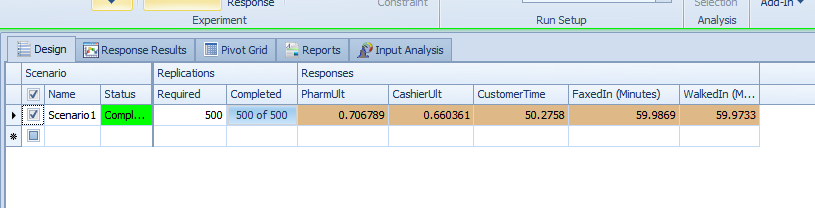

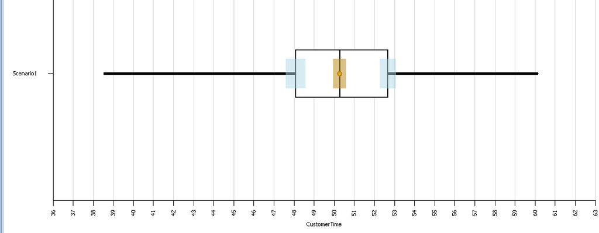